# Session 12: Semester Review

**Interactive mode:** click a code block or *Show Plot* button to reveal/hide its corresponding plot.

# Semester Review: Exploratory Data Analysis & Regression

This document provides a comprehensive review of the topics covered this semester, including data loading, wrangling, summarization, visualization, and regression. We will perform an exploratory data analysis (EDA) and a simple regression on the American National Election Studies (ANES) 2020 dataset.

## 1. Setup: Loading Packages

First, we need to load the necessary packages. The `tidyverse` package is a collection of R packages designed for data science, including `dplyr` for data manipulation and `ggplot2` for visualization.

```r
# If you haven't installed it yet, uncomment and run the line below
# if (FALSE) install.packages("tidyverse")

library(tidyverse)
```

## 2. Data Loading

```r
# URL for the ANES 2020 dataset
anes_data <- readRDS("anes_pilot_2020.RDS")



haven::write_dta(anes_data,"anes_pilot_2020.dta")

saveRDS(anes_data,"anes_pilot_2020.RDS")

write.csv(anes_data,"anes_pilot_2020.csv")
```

## 3. Initial Data Exploration

Before diving into analysis, let’s get a first look at our data. We can use functions like `glimpse()` to see the structure and `summary()` for a statistical overview.

```r
# Glimpse shows variable types and first few values
glimpse(anes_data)
```

```
## Rows: 3,080
## Columns: 470
## $ V1                   <dbl> 1451, 2875, 859, 2031, 587, 183, 1366, 1194, 2356, 2049, 1174, 2050, …
## $ StartDate            <chr> "4/12/2020 17:04", "4/16/2020 10:14", "4/17/2020 21:34", "4/16/2020 1…
## $ EndDate              <chr> "4/12/2020 17:23", "4/16/2020 11:06", "4/17/2020 22:32", "4/16/2020 1…
## $ `_v1`                <dbl> 1131, 3170, 3490, 3885, 2330, 1435, 4856, 2971, 1550, 4661, 3228, 416…
## $ RecordedDate         <chr> "4/12/2020 17:23", "4/16/2020 11:06", "4/17/2020 22:32", "4/16/2020 1…
## $ ResponseId           <chr> "R_3oBJppI62KNh4MC", "R_1jdLlxoKBpgExZS", "R_ClTXw6WOcfMOLWp", "R_3sj…
## $ qmetadata_Browser    <chr> "Chrome", "Firefox", "Chrome", "Chrome", "Chrome", "Chrome", "Safari …
## $ qmetadata_Version    <chr> "81.0.4044.96", "52", "81.0.4044.111", "78.0.3904.96", "80.0.3987.132…
## $ `_v2`                <chr> "Android 9", "Windows NT 5.1", "Android 9", "Android 7.1.1", "Windows…
## $ qmetadata_Resolution <chr> "360x760", "1024x768", "360x760", "320x570", "1920x1080", "1536x864",…
## $ follow               <dbl+lbl> 1, 2, 2, 2, 4, 2, 3, 1, 1, 2, 1, 2, 4, 3, 1, 2, 2, 1, 1, 1, 1, 1,…
## $ reg1                 <dbl+lbl> 1, 1, 4, 1, 1, 3, 1, 2, 1, 1, 1, 2, 1, 1, 1, 1, 1, 1, 1, 1, 3, 1,…
## $ votemail1a           <dbl+lbl> 4, 5, 4, 6, 1, 1, 4, 7, 2, 1, 1, 2, 4, 1, 1, 4, 2, 2, 1, 3, 2, 4,…
```

[output cut: 457 more lines]

```r
# Summary provides descriptive statistics
summary(anes_data$age)
```

```
##    Min. 1st Qu.  Median    Mean 3rd Qu.    Max.
##   18.00   34.75   49.00   48.87   63.00  110.00
```

```r
summary(anes_data$income)
```

```
##    Min. 1st Qu.  Median    Mean 3rd Qu.    Max.
##    1.00    6.00   11.00   12.52   20.00   99.00
```

```r
summary(anes_data$pid7)
```

```
##    Min. 1st Qu.  Median    Mean 3rd Qu.    Max.
##   1.000   2.000   4.000   4.197   7.000   9.000
```

## 4. Data Wrangling with dplyr

The raw dataset is massive. We will select a few key variables and clean them up for our analysis. We will focus on vote choice, party identification, age, and income.

- `select()`: to choose specific columns.
- `filter()`: to remove rows with missing data.
- `mutate()` and `case_when()`: to recode variables into more meaningful categories.
- `rename()`: to give variables understandable names.

```r
anes_clean <- anes_data %>%
   select(
    vote_choice = vote20jb,        # 2020 Biden vote (binary: voted for Biden)
    party_id = pid7,               # Party identification (7-point scale)
    age = age,                     # Age in years
    income = income                # Household income (percentile)
  ) %>%
  filter(
    !is.na(vote_choice),          # Remove missing values
    !is.na(party_id),
    !is.na(age),
    !is.na(income),
    age > 0,                       # Ensure valid age values
    income < 99,                     # Ensure valid income values
    party_id < 9,                          # Ensure valid party ID values
    vote_choice <3               # Care about Trump vs. Biden only

  ) %>%
  mutate(
    party = case_when(
      party_id %in% c(1, 2, 3) ~ "Republican",
      party_id == 4 ~ "Independent",
      party_id %in% c(5, 6, 7) ~ "Democrat",
      TRUE ~ NA
    ),
    party = factor(party, levels = c("Democrat", "Independent", "Republican")),
    vote_biden = ifelse(vote_choice == 2, 1, 0) # 1 if voted for Biden, 0 Trump
    )


# View the first few rows of our cleaned data
head(anes_clean)
```

| vote_choice | party_id | age | income | party | vote_biden |
| --- | --- | --- | --- | --- | --- |
| 1 | 2 | 27 | 10 | Republican | 0 |
| 1 | 1 | 60 | 7 | Republican | 0 |
| 1 | 1 | 65 | 1 | Republican | 0 |
| 2 | 7 | 53 | 11 | Democrat | 1 |
| 1 | 6 | 22 | 9 | Democrat | 0 |
| 2 | 5 | 27 | 14 | Democrat | 1 |

## 5. Data Summary

Now that our data is clean, we can create summary statistics. Let’s calculate the average age for each political party affiliation using `group_by()` and `summarise()`.

```r
party_summary <- anes_clean %>%
  group_by(party) %>%
  summarise(
    average_age = mean(age, na.rm = TRUE),
    median_income = median(income, na.rm = TRUE),
    count = n()
  ) %>%
  arrange(desc(average_age)) # Sort by average age

# Print the summary table
print(party_summary)
```

```
## # A tibble: 3 × 4
##   party       average_age median_income count
##   <fct>             <dbl>         <dbl> <int>
## 1 Republican         51.8            13  1109
## 2 Independent        51.1            10   198
## 3 Democrat           48.6            11  1267
```

## 6. Data Visualization with ggplot2

Visualizations help us understand patterns in the data. `ggplot2` allows us to create beautiful, layered graphics.

## Histogram of Respondent Age

A histogram shows the distribution of a single continuous variable.

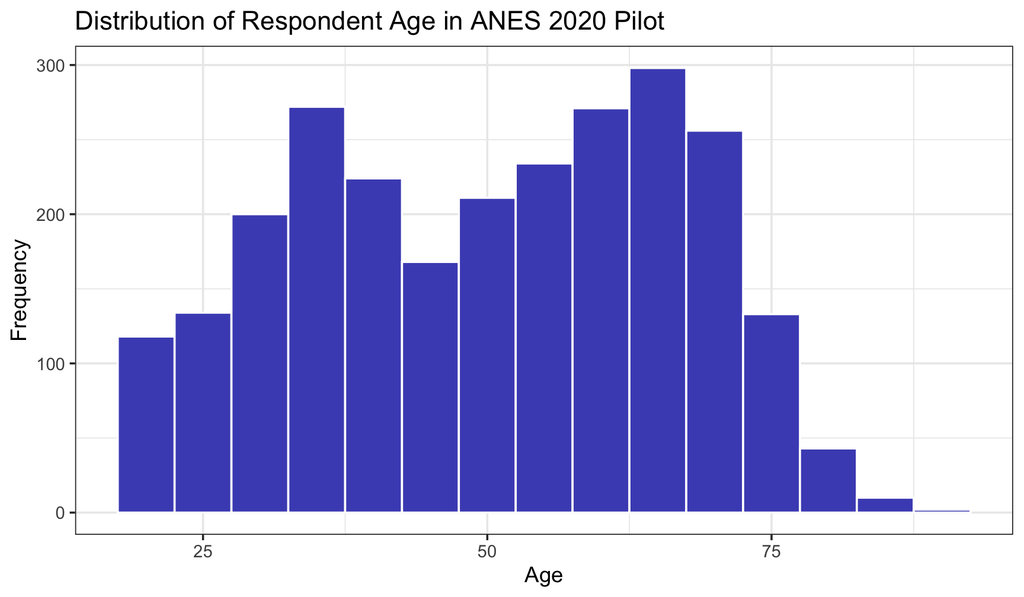

```r
ggplot(anes_clean, aes(x = age)) +
  geom_histogram(binwidth = 5, fill = "#4c51bf", color = "white") +
  labs(
    title = "Distribution of Respondent Age in ANES 2020 Pilot",
    x = "Age",
    y = "Frequency"
  ) +
  theme_bw()
```

## Bar Plot of Party Identification

A bar plot is great for showing the frequency of different categories.

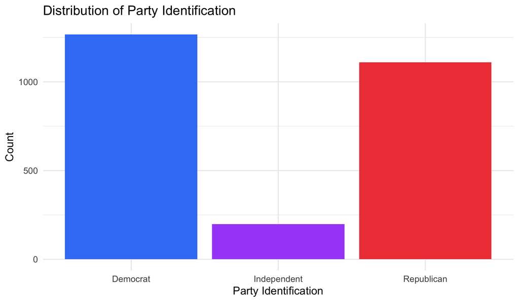

```r
ggplot(anes_clean, aes(x = party, fill = party)) +
  geom_bar() +
  labs(
    title = "Distribution of Party Identification",
    x = "Party Identification",
    y = "Count"
  ) +
  theme_minimal() +
  scale_fill_manual(values = c("Democrat" = "#3b82f6", "Republican" = "#ef4444", "Independent" = "#a855f7")) +
  theme(legend.position = "none")
```

## Boxplot of Age by Party

A boxplot is excellent for comparing the distribution of a continuous variable across different categories.

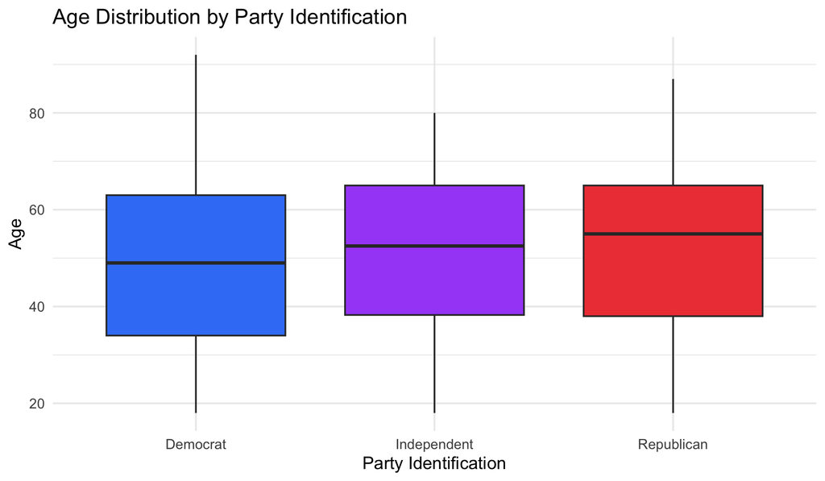

```r
ggplot(anes_clean, aes(x = party, y = age, fill = party)) +
  geom_boxplot() +
  labs(
    title = "Age Distribution by Party Identification",
    x = "Party Identification",
    y = "Age"
  ) +
  theme_minimal() +
  scale_fill_manual(values = c("Democrat" = "#3b82f6", "Republican" = "#ef4444", "Independent" = "#a855f7")) +
  theme(legend.position = "none")
```

## Scatter Plot: Income vs Age by Party

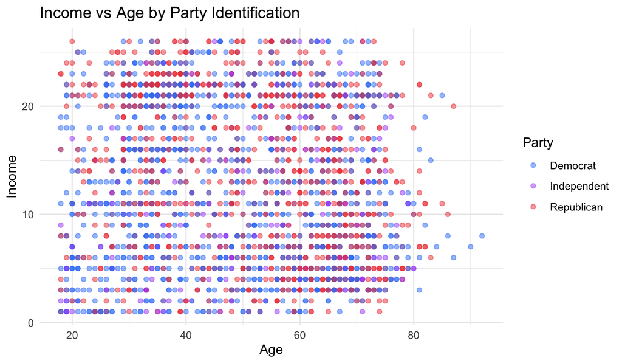

```r
ggplot(anes_clean, aes(x = age, y = income, color = party)) +
  geom_point(alpha = 0.5) +
  labs(
    title = "Income vs Age by Party Identification",
    x = "Age",
    y = "Income",
    color = "Party"
  ) +
  theme_minimal() +
  scale_color_manual(values = c("Democrat" = "#3b82f6", "Republican" = "#ef4444", "Independent" = "#a855f7"))
```

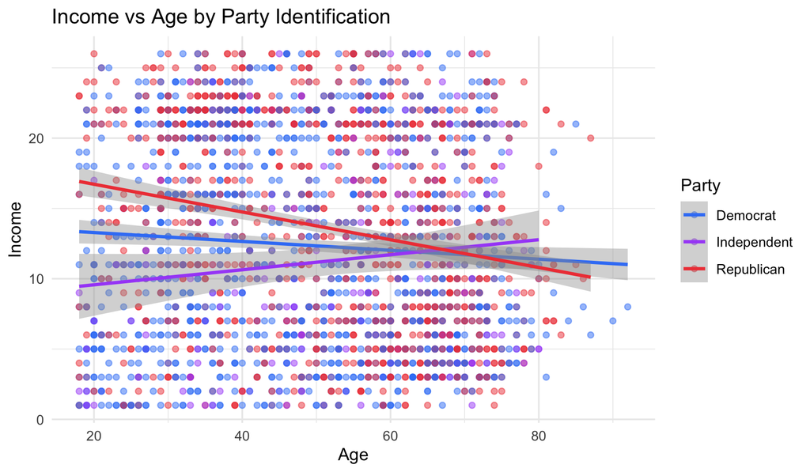

```r
ggplot(anes_clean, aes(x = age, y = income, color = party)) +
  geom_point(alpha = 0.5) +
  geom_smooth(method = "lm", se = T) +  # one fitted line per party
  labs(
    title = "Income vs Age by Party Identification",
    x = "Age",
    y = "Income",
    color = "Party"
  ) +
  theme_minimal() +
  scale_color_manual(values = c("Democrat" = "#3b82f6", "Republican" = "#ef4444", "Independent" = "#a855f7"))
```